# More Individuals Hypothesis

Simulation ideas

Tim Szewczyk

2017 April 12

# Background

The More Individuals Hypothesis (MIH) posits that communities with more individuals will contain more species, attempting to link productivity to diversity mechanistically. The empirical support is variable, with many studies failing to find a linear relationship between the number of individuals and the number of species and instead finding stronger support for a unimodal relationship.

One implicit assumption is that the abundances of each species (or perhaps the community as a whole) are relatively invariant across years. That is obviously not the case for individual species, most of which show dramatic & stochastic fluctations interannually in abundance. Simulations show that this stochasticity inhibits our ability to detect long-term changes in carrying capacity due to climate change; they may do the same to our ability to detect associations between total abundance and species richness for a given community.

These simulations quantify the effects of interannual stochasticity in a theoretical (computerized) environment with population parameters and underlying relationships pre-determined.

# Simulation description

[output not shown]

For each community, the abundances of all *i* species in the community will be simulated using Ricker models for each species in each of *t* years, with *s* simulations. The output for each community will be a 3-dimensional array (*i*, *t*, *s*).

One option is to model *j* communities with different species richnesses, with an explicit underlying positive relationship between S and K.comm. The model output could then be compared to look for that relationship. With no stochasticity, every simulation produces the expected linear relationship between S and N.comm:

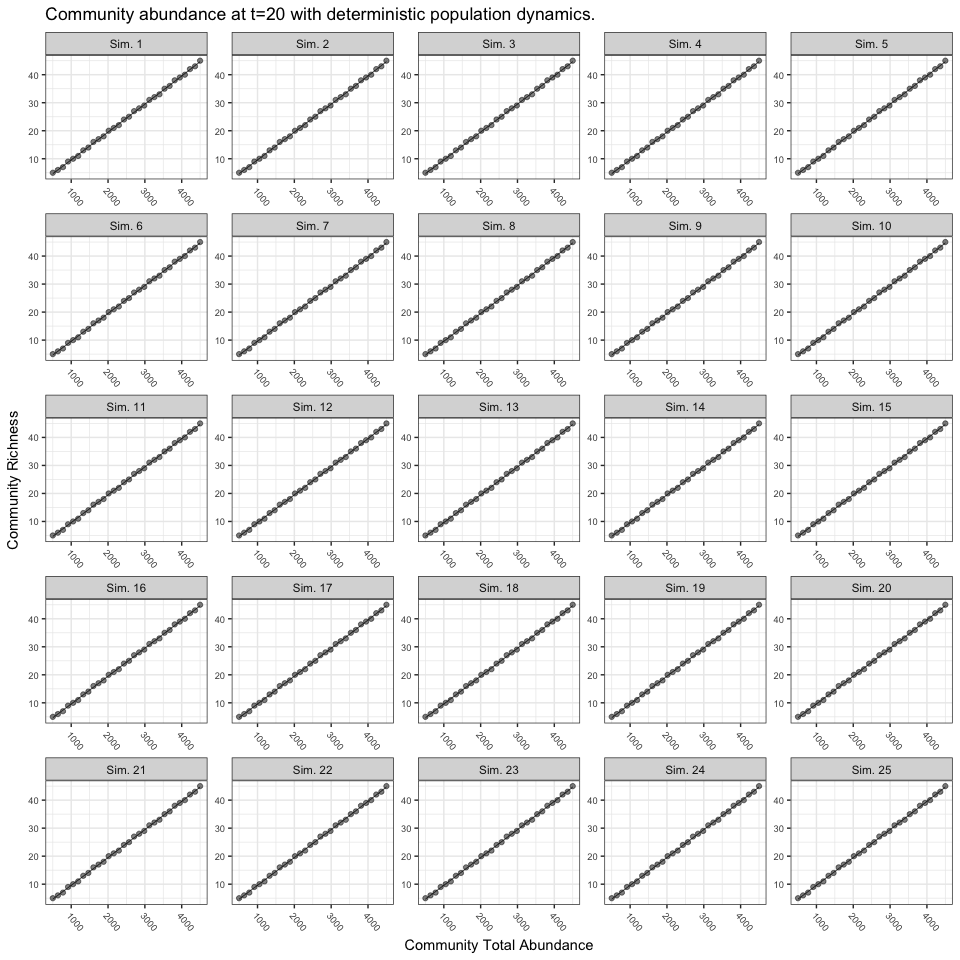

With stochasticity incorporated into the growth rate for each species, the observed pattern becomes much more variable:

[figure not shown]

For each simulation, we could fit a linear model, quadratic, etc and use AIC to determine the best model. Then, the main output to analyze would be the proportion of simulations best described by each model. The models to evaluate are easily updated in the *fit.mods( )* function.

Details that need to be decided:

- Distribution for *K* (Broken stick, geometric series, Fisher’s log-series, Zipf-Mandelbrodt, Metacommunity zero-sum multinomial, Pareto, compound Poisson-gamma, Poisson-lognormal, compound Poisson-exponential, Puyeo’s power-bend discrete, power discrete, etc – many options in *sads* package)
- Within a simulation, $r_i$ and $\sigma^2_i$ are set for all species, then communities are built from nested subsets of these species, such that all species in community *j* are also in community *j+1*. However, $K_i$ is determined randomly in each community. So while the population growth parameters for each species are constant across communities, the carrying capacities are not. To model a linear relationship between S and K.comm, I think this might be unavoidable.
- Which models to compare. Currently:
  - S ~ N.comm
  - S ~ log(N.comm)
  - S ~ N.comm + N.comm<sup>2</sup>